# Bayesian GLM Part1

Author

Murray Logan

Published

09/09/2025

# 1 Preparations

Load the necessary libraries

```r
library(tidyverse) # for data wrangling etc
library(rstanarm) # for fitting models in STAN
library(cmdstanr) # for cmdstan
library(brms) # for fitting models in STAN
library(standist) # for exploring distributions
library(coda) # for diagnostics
library(bayesplot) # for diagnostics
library(ggmcmc) # for MCMC diagnostics
library(DHARMa) # for residual diagnostics
library(rstan) # for interfacing with STAN
library(emmeans) # for marginal means etc
library(broom) # for tidying outputs
library(tidybayes) # for more tidying outputs
library(HDInterval) # for HPD intervals
library(ggeffects) # for partial plots
library(broom.mixed) # for summarising models
library(posterior) # for posterior draws
library(ggeffects) # for partial effects plots
library(patchwork) # for multi-panel figures
library(bayestestR) # for ROPE
library(see) # for some plots
library(easystats) # framework for stats, modelling and visualisation
library(INLA) # for approximate Bayes
library(INLAutils) # for additional INLA outputs
library(modelsummary) # for data and model summaries
theme_set(theme_grey()) # put the default ggplot theme back
source("helperFunctions.R")
bayesplot_theme_set(theme_bw(base_size = 8, base_family = "sans"))
```

# 2 Scenario

Here is an example from Fowler, Cohen, and Jarvis (1998). An agriculturalist was interested in the effects of fertilizer load on the yield of grass. Grass seed was sown uniformly over an area and different quantities of commercial fertilizer were applied to each of ten 1 m<sup>2</sup> randomly located plots. Two months later the grass from each plot was harvested, dried and weighed. The data are in the file **fertilizer.csv** in the **data** folder.

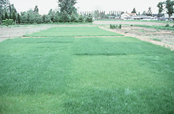

**Figure** 1: Field of grass

**Table** 1: Format of the fertilizer.csv data file

| FERTILIZER | YIELD |
| --- | --- |
| 25 | 84 |
| 50 | 80 |
| 75 | 90 |
| 100 | 154 |
| 125 | 148 |
| ... | ... |

**Table** 2: Description of the variables in the fertilizer data file

| **FERTILIZER**: | Mass of fertilizer (g.m<sup>-2</sup>) - Predictor variable |
| --- | --- |
| **YIELD**: | Yield of grass (g.m<sup>-2</sup>) - Response variable |

The aim of the analysis is to investigate the relationship between fertilizer concentration and grass yield.

# 3 Read in the data

We will start off by reading in the Fertilizer data. There are many functions in R that can read in a CSV file. We will use a the `read_csv()` function as it is part of the tidyverse ecosystem.

```r
fert <- read_csv("../data/fertilizer.csv", trim_ws = TRUE)
```

After reading in a dataset, it is always a good idea to quickly explore a few summaries in order to ascertain whether the imported data are correctly transcribed. In particular, we should pay attention to whether there are any unexpected missing values and ensure that each variable (column) has the expected class (e.g. that variables we expected to be considered numbers are indeed listed as either `<dbl>` or `<int>` and not `<char>`).

**glimpse**

```r
glimpse(fert)
```

```
Rows: 10
Columns: 2
$ FERTILIZER <dbl> 25, 50, 75, 100, 125, 150, 175, 200, 225, 250
$ YIELD      <dbl> 84, 80, 90, 154, 148, 169, 206, 244, 212, 248
```

**head**

```r
## Explore the first 6 rows of the data
head(fert)
```

```
# A tibble: 6 × 2
  FERTILIZER YIELD
       <dbl> <dbl>
1         25    84
2         50    80
3         75    90
4        100   154
5        125   148
6        150   169
```

**str**

```r
str(fert)
```

```
spc_tbl_ [10 × 2] (S3: spec_tbl_df/tbl_df/tbl/data.frame)
 $ FERTILIZER: num [1:10] 25 50 75 100 125 150 175 200 225 250
 $ YIELD     : num [1:10] 84 80 90 154 148 169 206 244 212 248
 - attr(*, "spec")=
  .. cols(
  ..   FERTILIZER = col_double(),
  ..   YIELD = col_double()
  .. )
 - attr(*, "problems")=<externalptr>
```

**Easystats (datawizard)**

```r
fert |> datawizard::data_codebook()
```

```
fert (10 rows and 2 variables, 2 shown)

ID | Name       | Type    | Missings |    Values |  N
---+------------+---------+----------+-----------+---
1  | FERTILIZER | numeric | 0 (0.0%) | [25, 250] | 10
---+------------+---------+----------+-----------+---
2  | YIELD      | numeric | 0 (0.0%) | [80, 248] | 10
-----------------------------------------------------
```

**Skim (modelsummary)**

Unique

Missing Pct.

Mean

SD

Min

Median

Max

Histogram

FERTILIZER

10

0

137.5

75.7

25.0

137.5

250.0

[figure not shown]

YIELD

10

0

163.5

64.0

80.0

161.5

248.0

[figure not shown]

```r
fert |> modelsummary::datasummary_skim()
```

# 4 Exploratory data analysis

The individual responses ($y_i$, observed yields) are each expected to have been **independently** drawn from normal (**Gaussian**) distributions ($\mathcal{N}$). These distributions represent all the possible yields we could have obtained at the specific ($i^{th}$) level of Fertilizer. Hence the $i^{th}$ yield observation is expected to have been drawn from a normal distribution with a mean of $\mu_i$.

Although each distribution is expected to come from populations that differ in their means, we assume that all of these distributions have the **same variance** ($\sigma^2$).

We need to supply priors for each of the parameters to be estimated ($\beta_0$, $\beta_1$ and $\sigma$). Whilst we want these priors to be sufficiently vague as to not influence the outcomes of the analysis (and thus be equivalent to the frequentist analysis), we do not want the priors to be so vague (wide) that they permit the MCMC sampler to drift off into parameter space that is both illogical as well as numerically awkward.

As a starting point, lets assign the following priors (how we arrive on these values will be outlined in sections on defining priors):

- $\beta_0$: Normal prior centred at 164 with a variance of 65
- $\beta_1$: Normal prior centred at 0 with a variance of 1
- $\sigma$: either a half cauchy centred at 0 with a variance of 2 or an exponential with parameter of 0.016

Note, when fitting models through either `rstanarm` or `brms`, the priors assume that the predictor(s) have been centred and are to be applied on the link scale. In this case the link scale is an identity.

Model formula:

$$\begin{align}
y_i &\sim{} \mathcal{N}(\mu_i, \sigma^2)\\
\mu_i &= \beta_0 + \beta_1 x_i\\
\beta_0 &\sim{} \mathcal{N}(164, 90)\\
\beta_1 &\sim{} \mathcal{N}(0, 90)\\
\sigma &\sim{} \mathcal{t}(3,0,90)\\
\end{align}$$

We intend to explore the relationship between Yield and Fertiliser using simple linear regression. Such an analysis assumes:

- **Normality**: each population is assumed to be normally distributed. This can be initially assessed by exploring the distribution of the response via either boxplots, violin plots or histograms (depending on sample size).
- **Homogeneity of variance**: each population is assumed to be equally varied. This can be initially assessed by exploring the distribution of observed values around an imaginary line of best fit through the cloud of data formed by a scatterplot of Yield against Fertiliser. If the spread of points increases (or decreases) along the trend line, it is likely that the populations are not equally varied.
- **Linearity**: in fitting a straight line through the cloud of data, we are assuming that a linear trend is appropriate. If the trend is not linear, then the inferred relationship may be miss-representative of the true relationship. In addition to an imaginary line, we could fit either a loess or linear smoother through the cloud to help us assess the likelihood of non-linearity.
- **Independence**: to help ensure that the estimates are unbiased, we must assume that all observations are independent. In this case, we assume that the observations were collected from a randomised design in which the level of Fertiliser was applied randomly to the different patches of the field. If however, the researchers had simply moved along the field applying progressively higher Fertiliser concentrations, then there is a chance that they have introduced additional biases or confounding factors. Similarly, if the Fertiliser levels were applied in increasing doses over time, there might also be biases. In the absence of any spatial or temporal information associated with the collection of data, we cannot directly assess this assumption.

**scatterplot**

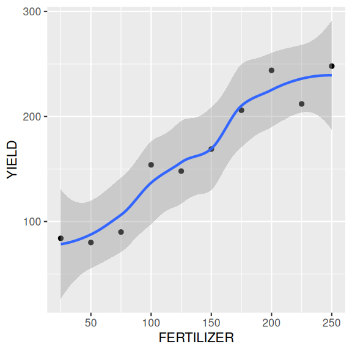

```r
ggplot(fert, aes(y = YIELD, x = FERTILIZER)) +
  geom_point() +
  geom_smooth()
```

**linear smoother**

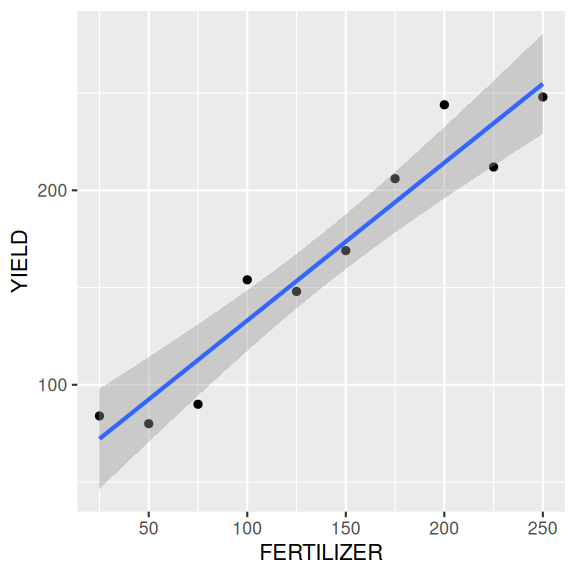

```r
ggplot(fert, aes(y = YIELD, x = FERTILIZER)) +
  geom_point() +
  geom_smooth(method = "lm")
```

**boxplots**

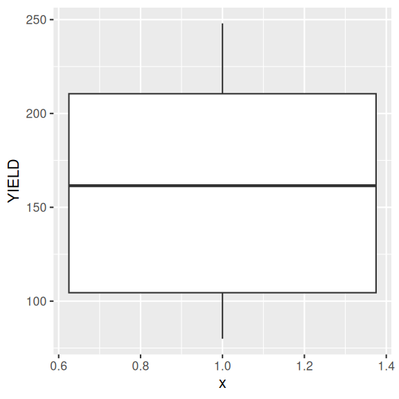

```r
ggplot(fert, aes(y = YIELD)) +
  geom_boxplot(aes(x = 1))
```

**violin plots**

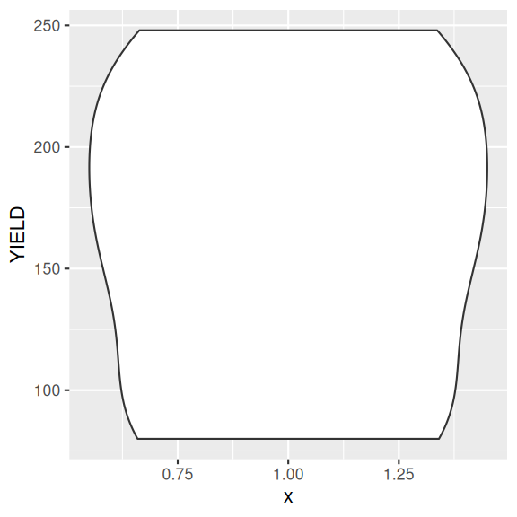

```r
ggplot(fert, aes(y = YIELD)) +
  geom_violin(aes(x = 1))
```

**histogram**

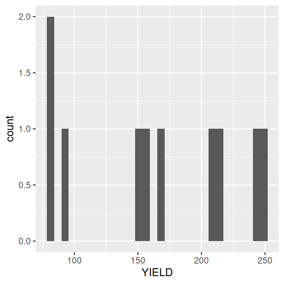

```r
ggplot(fert, aes(x = YIELD)) +
  geom_histogram()
```

**density plots**

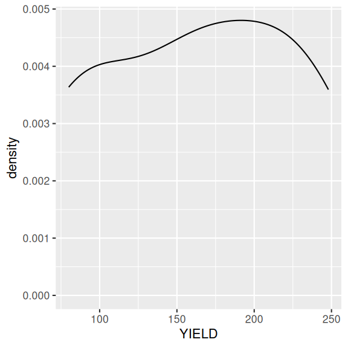

```r
ggplot(fert, aes(x = YIELD)) +
  geom_density()
```

**Conclusions**:

- there is no evidence of non-normality, non-homogeneity of variance or non-linearity
- we have no initial reason to suspect that the assumptions will not be satisfied and thus it is reasonable to assume that the results will be reliable.

# 5 Fit the model

Note, for routines that take more than a couple of seconds to perform (such as most Bayesian models), it is a good idea to cache the quarto or Rmarkdown chunks in which the routine is performed. That way, the routine will only be run the first time and any objects generated will be stored for future use. Thereafter, provided the code has not changed, the routine will not be re-run. Rather, `knitr` will just retrieve the cached objects and continue on.

One of the most difficult aspects of performing Bayesian analyses is the specification of priors. For instances where there are some previous knowledge available and a desire to incorporate those data, the difficulty is in how to ensure that the information is incorporated correctly. However, for instances where there are no previous relevant information and so a desire to have the posteriors driven entirely by the new data, the difficulty is in how to define priors that are both vague enough (not bias results in their direction) and yet not so vague as to allow the MCMC sampler to drift off into unsupported regions (and thus get stuck and yield spurious estimates).

For early implementations of MCMC sampling routines (such as Metropolis Hasting and Gibbs), it was fairly common to see very vague priors being defined. For example, the priors on effects, were typically normal priors with mean of 0 and variance of `1e+06` (1,00,000). These are very vague priors. Yet for some samplers (e.g. NUTS), such vague priors can encourage poor behaviour of the sampler - particularly if the posterior is complex. It is now generally advised that priors should (where possible) be somewhat **weakly informative** and to some extent, represent the bounds of what are feasible and sensible estimates.

The degree to which priors **influence** an outcome (whether by having a pulling effect on the estimates or by encouraging the sampler to drift off into unsupported regions of the posterior) is dependent on:

- the relative sparsity of the data - the larger the data, the less weight the priors have and thus less influence they exert.
- the complexity of the model (and thus posterior) - the more parameters, the more sensitive the sampler is to the priors.

The sampled posterior is the product of both the likelihood and the prior - all of which are multidimensional. For most applications, it would be vertically impossible to define a sensible multidimensional prior. Hence, our only option is to define priors on individual parameters (e.g. the intercept, slope(s), variance etc) and to hope that if they are individually sensible, they will remain collectively sensible.

So having (hopefully) impressed upon the notion that priors are an important consideration, I will now attempt to synthesise some of the approaches that can be employed to arrive at weakly informative priors that have been gleaned from various sources. Largely, this advice has come from the following resources:

- https://github.com/stan-dev/stan/wiki/Prior-Choice-Recommendations
- http://svmiller.com/blog/2021/02/thinking-about-your-priors-bayesian-analysis/

I will outline some of the current main recommendations before summarising some approaches in a table.

- weakly informative priors should contain enough information so as to regularise (discourage unreasonable parameter estimates whilst allowing all reasonable estimates).
- for effects parameters on scaled data, an argument could be made for a normal distribution with a standard deviation of 1 (e.g. `normal(0,1)`), although some prefer a t distribution with 3 degrees of freedom and standard deviation of 1 (e.g. `student_t(3,0,1)`) - apparently a flatter t is a more robust prior than a normal as an uninformative prior…
- for unscaled data, the above priors can be scaled by using the standard deviation of the data as the prior standard deviation (e.g. `student_t(3,0,sd(y))`, or `student_t(3,0,sd(y)/sd(x))`)
- for priors of hierachical standard deviations, priors should encourage shrinkage towards 0 (particularly if the number of groups is small, since otherwise, the sampler will tend to be more responsive to “noise”).

| Family | Parameter | brms | rstanarm |
| --- | --- | --- | --- |
| Gaussian | Intercept | `student_t(3,median(y),mad(y))` | `normal(mean(y),2.5*sd(y))` |
|  | ‘Population effects’ (slopes, betas) | flat, improper priors | `normal(0,2.5*sd(y)/sd(x))` |
|  | Sigma | `student_t(3,0,mad(y))` | `exponential(1/sd(y))` |
|  | ‘Group-level effects’ | `student_t(3,0,mad(y))` | `decov(1,1,1,1)` |
|  | Correlation on group-level effects | `ljk_corr_cholesky(1)` |  |
| Poisson | Intercept | `student_t(3,median(y),mad(y))` | `normal(mean(y),2.5*sd(y))` |
|  | ‘Population effects’ (slopes, betas) | flat, improper priors | `normal(0,2.5*sd(y)/sd(x))` |
|  | ‘Group-level effects’ | `student_t(3,0,mad(y))` | `decov(1,1,1,1)` |
|  | Correlation on group-level effects | `ljk_corr_cholesky(1)` |  |
| Negative binomial | Intercept | `student_t(3,median(y),mad(y))` | `normal(mean(y),2.5*sd(y))` |
|  | ‘Population effects’ (slopes, betas) | flat, improper priors | `normal(0,2.5*sd(y)/sd(x))` |
|  | Shape | `gamma(0.01, 0.01)` | `exponential(1/sd(y))` |
|  | ‘Group-level effects’ | `student_t(3,0,mad(y))` | `decov(1,1,1,1)` |
|  | Correlation on group-level effects | `ljk_corr_cholesky(1)` |  |

Notes:

`brms`

https://github.com/paul-buerkner/brms/blob/c2b24475d727c8afd8bfc95947c18793b8ce2892/R/priors.R

1. In the above, for non-Gaussian families, `y` is first transformed according to the family link. If the family link is `log`, then 0.1 is first added to 0 values.
2. in `brms` the minimum standard deviation for the Intercept prior is `2.5`
3. in `brms` the minimum standard deviation for group-level priors is `10`.

`rstanarm`

http://mc-stan.org/rstanarm/articles/priors.html

1. in `rstanarm` priors on standard deviation and correlation associated with group-level effects are packaged up into a single prior (`decov` which is a decomposition of the variance and covariance matrix).

**frequentist**

For the purpose of comparing the frequentist and Bayesian outcomes, it might be useful to start by fitting the frequentist simple linear model. We will also fit this model with the predictor (fertilizer concentration) centred.

```r
summary(fert.lm <- lm(YIELD ~ FERTILIZER, data = fert))
```

```
Call:
lm(formula = YIELD ~ FERTILIZER, data = fert)

Residuals:
   Min     1Q Median     3Q    Max
-22.79 -11.07  -5.00  12.00  29.79

Coefficients:
            Estimate Std. Error t value Pr(>|t|)
(Intercept) 51.93333   12.97904   4.001  0.00394 **
FERTILIZER   0.81139    0.08367   9.697 1.07e-05 ***
---
Signif. codes:  0 '***' 0.001 '**' 0.01 '*' 0.05 '.' 0.1 ' ' 1

Residual standard error: 19 on 8 degrees of freedom
Multiple R-squared:  0.9216,    Adjusted R-squared:  0.9118
F-statistic: 94.04 on 1 and 8 DF,  p-value: 1.067e-05
```

```r
sigma(fert.lm)
```

```
[1] 18.99936
```

```r
summary(fert.lm <- lm(YIELD ~ center(FERTILIZER), data = fert))
```

```
Call:
lm(formula = YIELD ~ center(FERTILIZER), data = fert)

Residuals:
   Min     1Q Median     3Q    Max
-22.79 -11.07  -5.00  12.00  29.79

Coefficients:
                    Estimate Std. Error t value Pr(>|t|)
(Intercept)        163.50000    6.00813  27.213 3.58e-09 ***
center(FERTILIZER)   0.81139    0.08367   9.697 1.07e-05 ***
---
Signif. codes:  0 '***' 0.001 '**' 0.01 '*' 0.05 '.' 0.1 ' ' 1

Residual standard error: 19 on 8 degrees of freedom
Multiple R-squared:  0.9216,    Adjusted R-squared:  0.9118
F-statistic: 94.04 on 1 and 8 DF,  p-value: 1.067e-05
```

```r
sigma(fert.lm)
```

```
[1] 18.99936
```

```r
summary(fert.lm <- lm(YIELD ~ scale(FERTILIZER), data = fert))
```

```
Call:
lm(formula = YIELD ~ scale(FERTILIZER), data = fert)

Residuals:
   Min     1Q Median     3Q    Max
-22.79 -11.07  -5.00  12.00  29.79

Coefficients:
                  Estimate Std. Error t value Pr(>|t|)
(Intercept)        163.500      6.008  27.213 3.58e-09 ***
scale(FERTILIZER)   61.415      6.333   9.697 1.07e-05 ***
---
Signif. codes:  0 '***' 0.001 '**' 0.01 '*' 0.05 '.' 0.1 ' ' 1

Residual standard error: 19 on 8 degrees of freedom
Multiple R-squared:  0.9216,    Adjusted R-squared:  0.9118
F-statistic: 94.04 on 1 and 8 DF,  p-value: 1.067e-05
```

```r
sigma(fert.lm)
```

```
[1] 18.99936
```

**rstanarm**

**Using default priors**

In `rstanarm`, the default priors are designed to be weakly informative. They are chosen to provide moderate regularisation (to help prevent over-fitting) and help stabilise the computations.

```r
fert.rstanarm <- stan_glm(YIELD ~ scale(FERTILIZER),
  data = fert,
  iter = 5000,
  warmup = 1000,
  chains = 3,
  thin = 5,
  refresh = 0
)
```

In the above:

- the formula and data arguments should be familiar as they are the same as for many models in R
- iter: indicates the number of MCMC iterations to perform per chain
- warmup: indicates how many of the initial MCMC samples to exclude. During the warmup stage, the MCMC sampler is tuning its sampling operations to allow it to determine the best way to create the chain. While it is in this discovery phase, the estimates it produces might be unrepresentative.
- chains: indicates the number of independent chains to run. The more chains, the more random starts. The point of multiple random starts is to minimise the potential for the starting point to dictate the outcome. It is possible that a chain might get stuck sampling a single feature of the posterior and not discover additional features. Additional random starting points should hopefully alleviate this. Either 3 or 4 is typical.
- thin: indicates the rate at which the MCMC samples should be thinned in order to eliminate auto-correlation between MCMC samples. When the step lengths between MCMC samples are small, the resulting parameter estimates will be auto-correlated (since samples close by in the chain will be more similar than those far apart). The rate of thinning necessary will depend on the degree of auto-correlation. For stan models, a thinning rate of 5 is a good starting point.
- refresh: indicates how often the terminal display should be updated. When running a large model, this can be useful as it provides a form of progress. However, when the routine is within an Rmarkdown document, it just results in the output including each line of progress and a lot of space is taken up unnecessarily

Having allowed `rstanarm` to formulate its own weakly informative priors, it is a good idea to explore what they are. Firstly, out of curiosity, it might be interesting to see what it has chosen. However, more importantly, we need to be able to document what the priors were and the `rstanarm` development team make it very clear that there is no guarantee that the default priors will remain the same into the future.

```r
prior_summary(fert.rstanarm)
```

```
Priors for model 'fert.rstanarm'
------
Intercept (after predictors centered)
  Specified prior:
    ~ normal(location = 164, scale = 2.5)
  Adjusted prior:
    ~ normal(location = 164, scale = 160)

Coefficients
  Specified prior:
    ~ normal(location = 0, scale = 2.5)
  Adjusted prior:
    ~ normal(location = 0, scale = 160)

Auxiliary (sigma)
  Specified prior:
    ~ exponential(rate = 1)
  Adjusted prior:
    ~ exponential(rate = 0.016)
------
See help('prior_summary.stanreg') for more details
```

Nevertheless, `rstanarm` will return a posterior for intercept that is consistent with how the user had defined the linear predictor - that is, if the user does not centre the predictors, then `rstanarm` will return the intercept posterior on a scale consistent with as if the predictors had not been centred, even though they were automatically scaled internally.

When defining the spread of priors, `rstanarm` prefers to do so relative to the scaling of the data. For example, for the slope, it takes the ratio of the standard deviations of the response and the predictor and multiplies them by a factor of 2.5 (by default). Hence it is possible to define priors either in relative terms (by providing a scaling factor) or in absolute terms, by providing the desired priors along with the `autoscale = FALSE` *argument*.

The above prior summary tells us:

- for the intercept, it is using a normal prior with a mean of 164 and a standard deviation of 2.5. This mean value is based on the mean of the response variable (rounded up). The 2.5 is used for all intercepts. The scale of the prior is then adjusted proportional to the variability in the response, by multiplying 2.5 by the standard deviation of the response (and rounding up).

```r
mean(fert$YIELD)
```

```
[1] 163.5
```

```r
sd(fert$YIELD)
```

```
[1] 63.97439
```

```r
2.5 * sd(fert$YIELD)
```

```
[1] 159.936
```

- for the coefficients (in this case, just the slope), the default prior is a normal prior centred around 0 with a standard deviation of 2.5. This is then adjusted for the scale of the data by multiplying the 2.5 by the ratio of the standard deviation of the response to the standard deviation of the predictor (then rounded).

```r
2.5 * sd(fert$YIELD) / sd(fert$FERTILIZER)
```

```
[1] 2.113004
```

```r
2.5 * sd(fert$YIELD) / 1
```

```
[1] 159.936
```

- the auxiliary prior represents whatever additional prior is required for the nominated model. In the case of a Gaussian model, this will be $\sigma$, for negative binomial, it will be the reciprocal of dispersion, for gamma, it will be shape, etc . By default in `rstanarm`, this is a exponential with a rate of 1 which is then adjusted by division with the standard deviation of the response.

```r
1 / sd(fert$YIELD)
```

```
[1] 0.01563126
```

**Assessing priors**

One way to assess the priors is to have the MCMC sampler sample purely from the prior predictive distribution without conditioning on the observed data. Doing so provides a glimpse at the range of predictions possible under the priors. On the one hand, wide ranging predictions would ensure that the priors are unlikely to influence the actual predictions once they are conditioned on the data. On the other hand, if they are too wide, the sampler is being permitted to traverse into regions of parameter space that are not logically possible in the context of the actual underlying ecological context. Not only could this mean that illogical parameter estimates are possible, when the sampler is traversing regions of parameter space that are not supported by the actual data, the sampler can become unstable and have difficulty.

We can draw from the prior predictive distribution instead of conditioning on the response, by updating the model and indicating `prior_PD=TRUE`. After refitting the model in this way, we can plot the predictions to gain insights into the range of predictions supported by the priors alone.

```r
fert.rstanarm1 <- update(fert.rstanarm, prior_PD = TRUE)
```

```
Data points may overlap. Use the `jitter` argument to add some amount of
  random variation to the location of data points and avoid overplotting.
```

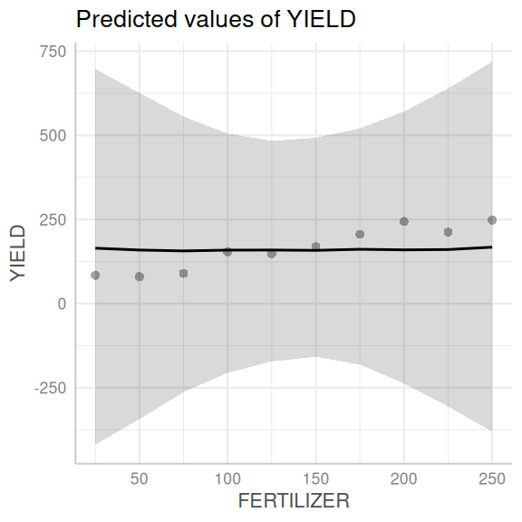

```r
ggpredict(fert.rstanarm1) |> plot(show_data = TRUE)
```

**Conclusions:**

- we see that the range of predictions is fairly wide and the slope could range from strongly negative to strongly positive.
- at the same time, massive yields are not supported, so there is some constraints on the parameters space
- nevertheless, negative yields are considered possible, even though these are clearly not logical.

**Defining priors**

The following link provides some guidance about defining priors. [https://github.com/stan-dev/stan/wiki/Prior-Choice-Recommendations]

When defining our own priors, we typically do not want them to be scaled.

If we wanted to define our own priors that were less vague, yet still not likely to bias the outcomes, we could try the following priors (mainly plucked out of thin air):

- $\beta_0$: normal centred at 164 with a standard deviation of 65
- $\beta_1$: normal centred at 0 with a standard deviation of 65
- $\sigma$: half-t (df = 3) centred at 0 with a standard deviation of 65

We can visualise each of the above as:

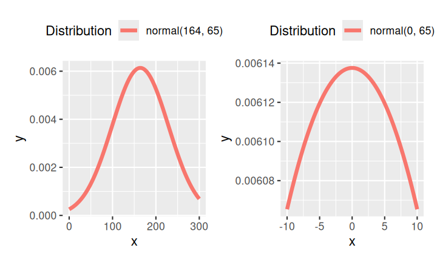

```r
standist::visualize("normal(164, 65)", xlim = c(0, 300)) +
  standist::visualize("normal(0, 65)", xlim = c(-10, 10))
```

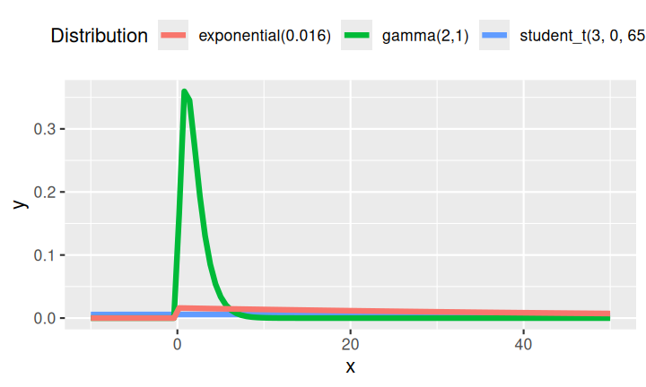

```r
standist::visualize("student_t(3, 0, 65)",
  "gamma(2,1)",
  "exponential(0.016)",
  xlim = c(-10, 50)
)
```

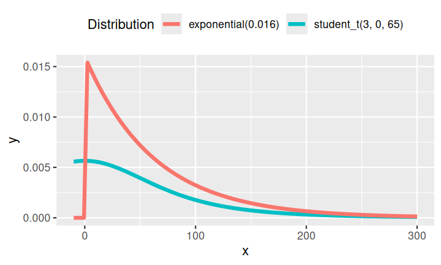

```r
standist::visualize("student_t(3, 0, 65)",
  "exponential(0.016)",
  xlim = c(-10, 300)
)
```

I will also overlay the raw data for comparison.

```r
fert.rstanarm2 <- stan_glm(YIELD ~ scale(FERTILIZER),
  data = fert,
  prior_intercept = normal(164, 65, autoscale = FALSE),
  prior = normal(0, 65, autoscale = FALSE),
  prior_aux = student_t(3, 0, 65, autoscale = FALSE),
  prior_PD = TRUE,
  iter = 5000, warmup = 1000,
  chains = 3, cores = 3,
  thin = 5, refresh = 0
)
```

```
Data points may overlap. Use the `jitter` argument to add some amount of
  random variation to the location of data points and avoid overplotting.
```

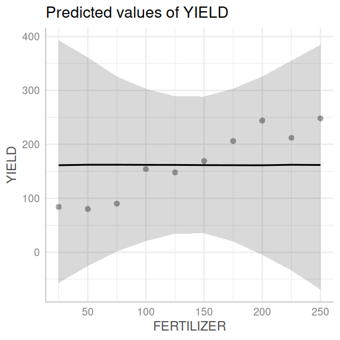

```r
ggpredict(fert.rstanarm2) |>
  plot(show_data = TRUE)
```

Now lets refit, conditioning on the data.

```r
fert.rstanarm3 <- update(fert.rstanarm2, prior_PD = FALSE)
```

**Plotting prior and posterior**

```
Drawing from prior...
```

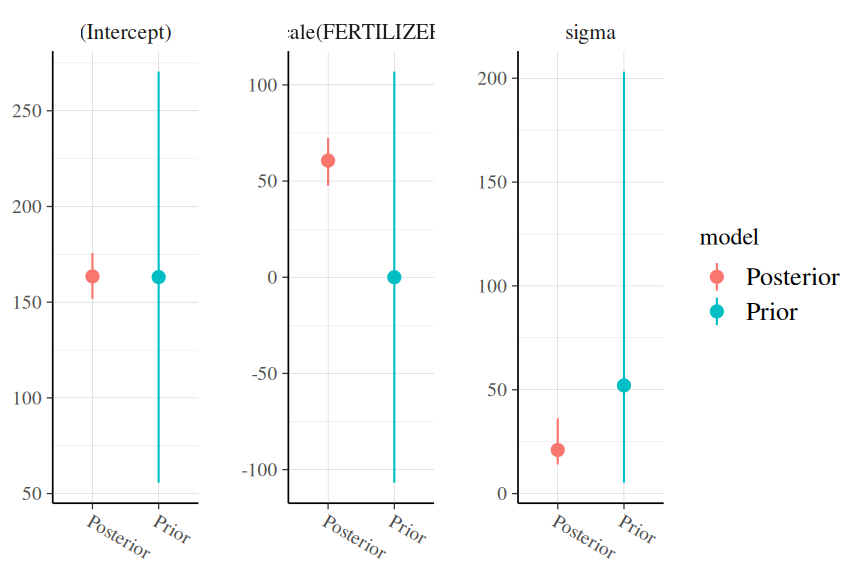

```r
posterior_vs_prior(fert.rstanarm3,
  color_by = "vs", group_by = TRUE,
  facet_args = list(scales = "free_y")
)
```

**Conclusions:**

- in each case, the prior is substantially wider than the posterior, suggesting that the posterior is not biased towards the prior.

```
Data points may overlap. Use the `jitter` argument to add some amount of
  random variation to the location of data points and avoid overplotting.
```

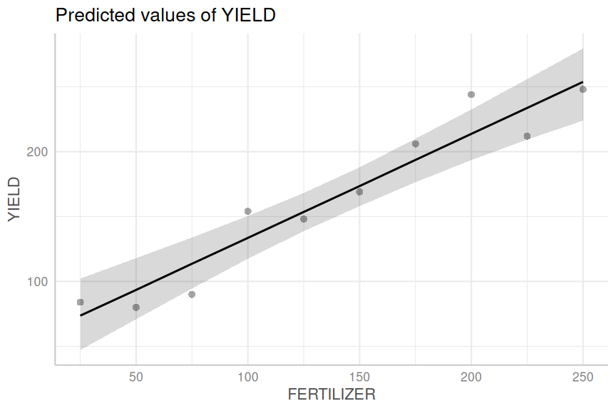

```r
ggpredict(fert.rstanarm3) |> plot(show_data = TRUE)
```

**brms**

**Using default priors**

In `brms`, the default priors are designed to be weakly informative. They are chosen to provide moderate regularisation (to help prevent over-fitting) and help stabilise the computations.

Unlike `rstanarm`, `brms` models must be compiled before they start sampling. For most models, the compilation of the stan code takes around 45 seconds.

```r
fert_form <- bf(YIELD ~ scale(FERTILIZER))
fert_brm <- brm(fert_form,
  data = fert,
  iter = 5000,
  warmup = 1000,
  chains = 3,
  thin = 5,
  refresh = 0,
  backend = "rstan"
)
```

In the above:

- the formula and data arguments should be familiar as they are the same as for many models in R. That said, the formula specification of `brms` can define models that are not possible by most other routines. To facilitate this enhanced functionality, we usually define a `brms` formula within its own `bf()` function along with the `family` (in this case, it is Gaussian, which is the default and therefore can be omitted.)
- iter: indicates the number of MCMC iterations to perform per chain
- warmup: indicates how many of the initial MCMC samples to exclude. During the warmup stage, the MCMC sampler is tuning its sampling operations to allow it to determine the best way to create the chain. While it is in this discovery phase, the estimates it produces might be unrepresentative.
- chains: indicates the number of independent chains to run. The more chains, the more random starts. The point of multiple random starts is to minimise the potential for the starting point to dictate the outcome. It is possible that a chain might get stuck sampling a single feature of the posterior and not discover additional features. Additional random starting points should hopefully alleviate this. Either 3 or 4 is typical.
- thin: indicates the rate at which the MCMC samples should be thinned in order to eliminate auto-correlation between MCMC samples. When the step lengths between MCMC samples are small, the resulting parameter estimates will be auto-correlated (since samples close by in the chain will be more similar than those far apart). The rate of thinning necessary will depend on the degree of auto-correlation. For stan models, a thinning rate of 5 is a good starting point.
- refresh: indicates how often the terminal display should be updated. When running a large model, this can be useful as it provides a form of progress. However, when the routine is within an Rmarkdown document, it just results in the output including each line of progress and a lot of space is taken up unnecessarily

The returned object (a list) contains a range of objects. The output from `rstan` is contained in the `fit` list item.

```r
fert_brm |> names()
```

```
 [1] "formula"   "data"      "prior"     "data2"     "stanvars"  "model"
 [7] "save_pars" "algorithm" "backend"   "threads"   "opencl"    "stan_args"
[13] "fit"       "basis"     "criteria"  "file"      "version"   "family"
[19] "autocor"   "ranef"     "cov_ranef" "stan_funs" "data.name"
```

Having allowed `brms` to formulate its own weakly informative priors, it is a good idea to explore what they are. Firstly, out of curiosity, it might be interesting to see what it has chosen. However, more importantly, we need to be able to document what the priors were and the `brms` development team make it very clear that there is no guarantee that the default priors will remain the same into the future.

```r
prior_summary(fert_brm)
```

```
                     prior     class            coef group resp dpar nlpar lb ub       source
                    (flat)         b                                                  default
                    (flat)         b scaleFERTILIZER                             (vectorized)
 student_t(3, 161.5, 90.4) Intercept                                                  default
     student_t(3, 0, 90.4)     sigma                                        0         default
```

This tells us:

- for the intercept, it is using a student t (flatter normal) prior with a mean of 161.5 and a standard deviation of 90.4. These mean and standard deviation values are based on the median and median absolute deviation of the response variable (rounded).

**Note, all priors are on the link scale and on scaled (e.g. standardized to a mean of 0 and standard deviation of 1) predictiors**

```r
median(fert$YIELD)
```

```
[1] 161.5
```

```r
mad(fert$YIELD)
```

```
[1] 90.4386
```

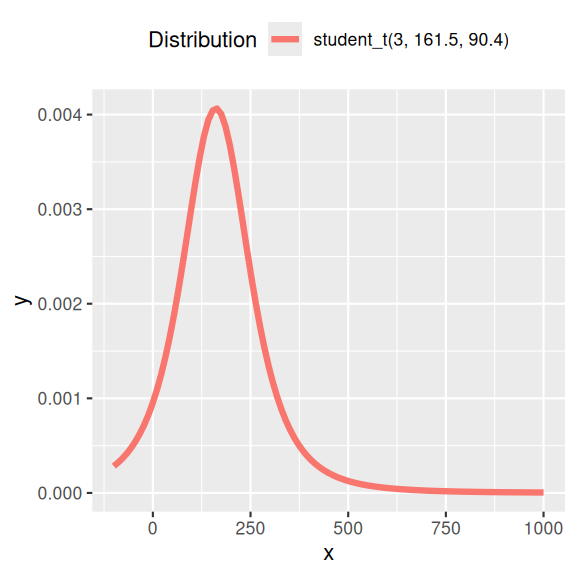

```r
standist::visualize("student_t(3, 161.5, 90.4)", xlim = c(-100, 1000))
```

- for the beta coefficients (in this case, just the slope), the default prior is a **improper flat prior**. A flat prior essentially means that any value between negative infinity and positive infinity are equally likely. Whilst this might seem reckless, in practice, it seems to work reasonably well for non-intercept beta parameters.
- the prior on sigma is also a student t (although only the positive half is used in the stan code), with mean of 0 and standard deviation of 90.4.

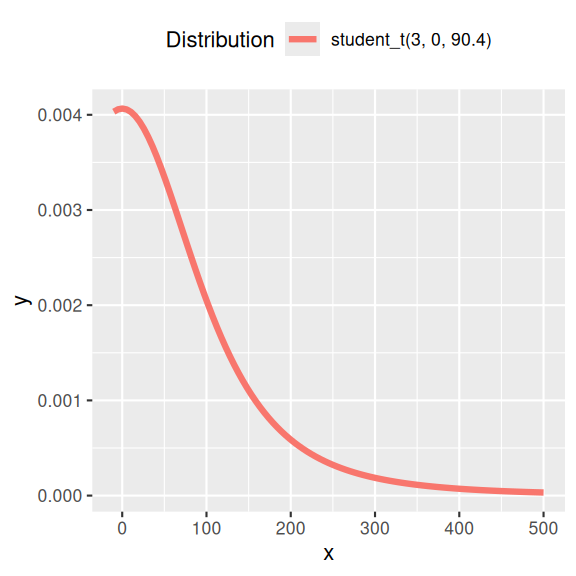

```r
standist::visualize("student_t(3, 0, 90.4)", xlim = c(-10, 500))
```

**Assessing default priors**

One way to assess the priors is to have the MCMC sampler sample purely from the prior predictive distribution without conditioning on the observed data. Doing so provides a glimpse at the range of predictions possible under the priors. On the one hand, wide ranging predictions would ensure that the priors are unlikely to influence the actual predictions once they are conditioned on the data. On the other hand, if they are too wide, the sampler is being permitted to traverse into regions of parameter space that are not logically possible in the context of the actual underlying ecological context. Not only could this mean that illogical parameter estimates are possible, when the sampler is traversing regions of parameter space that are not supported by the actual data, the sampler can become unstable and have difficulty.

In `brms`, we can inform the sampler to draw from the prior predictive distribution instead of conditioning on the response, by running the model with the `sample_prior = 'only'` argument. Unfortunately, this cannot be applied when there are flat priors (since the posteriors will necessarily extend to negative and positive infinity). Therefore, in order to use this useful routine, we need to make sure that we have defined a proper prior for all parameters.

Lets try a Gaussian (normal) distribution for the slope. We will start with what is likely to be a very wide distribution (wide with respect to what we know about the likely slope). `rstanarm` sets the default for such population-level effects at 2.5 times the ratio of standard deviations of the response and predictor. The reason that 2.5 is used is that in a standard normal distribution, a standard deviation of 2.5 encapsulates approximately 99% of the values. Hence, a standard deviation of 2.5 would represent reasonably wide expectations (priors). Given that the input data are unlikely to be standardised, we can instead standardise the priors by multiplying the 2.5 by the ratio of standard deviations of the response and predictor.

We could adopt similar logic here, but rather than use standard deviation, we could use median absolute deviation to be consistent with other prior specifications in `brms`. In this case, the prior standard deviation would be `2.5 * mad(fert$YIELD)/mad(fert$FERTILIZER)` = `2.44` (which I will round to 2.5). However, if we scale the predictor (which we should), then we are essentially dividing the `mad` or `sd` of the response by 1 (since the standard deviation of a scaled vector is 1). Hence, we the standard devation for the prior could just be `mad(fert$YIELD)`.

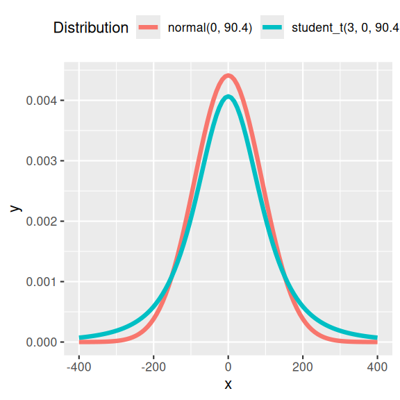

```r
standist::visualize("normal(0, 90.4)", "student_t(3, 0, 90.4)", xlim = c(-400, 400))
```

```r
fert_form <- bf(YIELD ~ scale(FERTILIZER))
fert_brm1 <- brm(fert_form,
  data = fert,
  prior = prior(student_t(3, 0, 90.4), class = "b"),
  sample_prior = "only",
  iter = 5000,
  warmup = 1000,
  chains = 3,
  thin = 5,
  backend = "rstan",
  refresh = 0
)
```

**ggpredict**

```
Data points may overlap. Use the `jitter` argument to add some amount of
  random variation to the location of data points and avoid overplotting.
```

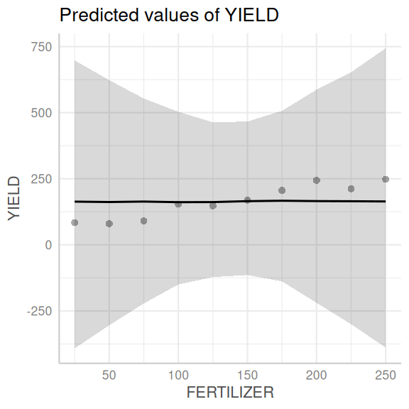

```r
fert_brm1 |>
  ggpredict() |>
  plot(show_data = TRUE)
```

**ggemmeans**

```
Data points may overlap. Use the `jitter` argument to add some amount of
  random variation to the location of data points and avoid overplotting.
```

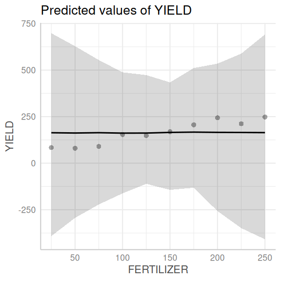

```r
fert_brm1 |>
  ggemmeans(~FERTILIZER) |>
  plot(show_data = TRUE)
```

**conditional_effects**

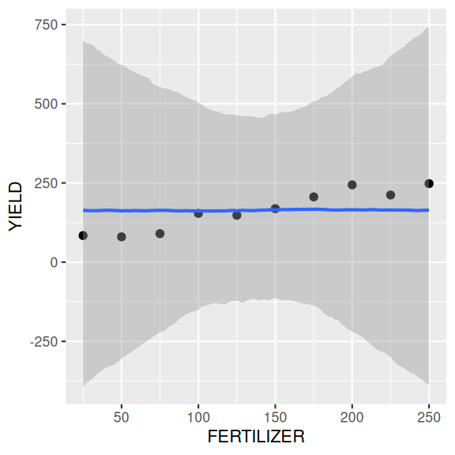

```r
fert_brm1 |>
  conditional_effects() |>
  plot(points = TRUE)
```

**Conclusions:**

- we see that the range of predictions is fairly wide and the slope could range from strongly negative to strongly positive.
- at the same time, massive yields are not supported, so there is some constraints on the parameters space
- nevertheless, negative yields are considered possible, even though these are clearly not logical.

**Defining priors**

The following link provides some guidance about defining priors. [https://github.com/stan-dev/stan/wiki/Prior-Choice-Recommendations]

When defining our own priors, we typically do not want them to be scaled.

If we wanted to define our own priors that were less vague, yet still not likely to bias the outcomes, we could try the following priors (which I have mainly plucked out of thin air):

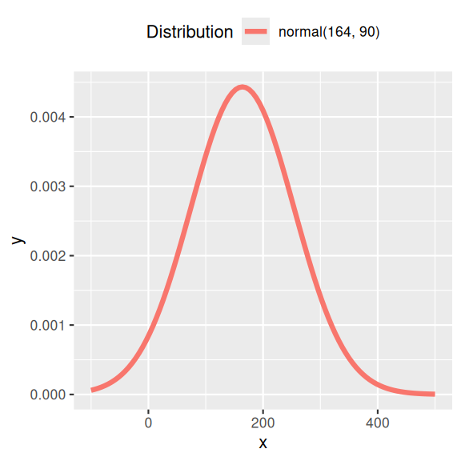

```r
standist::visualize("normal(164, 90)", xlim = c(-100, 500))
```

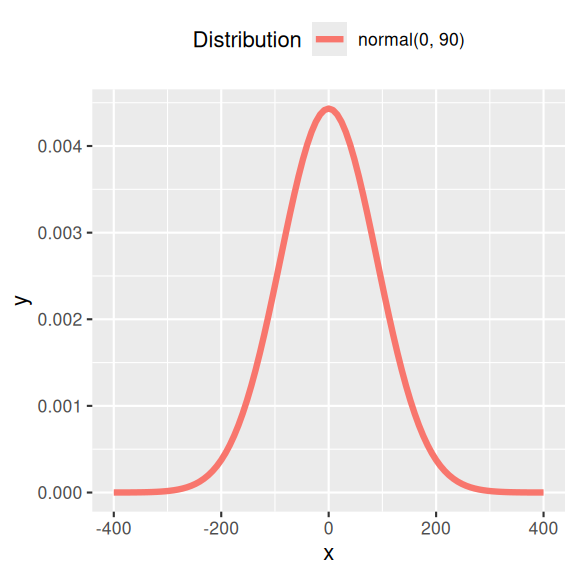

```r
standist::visualize("normal(0, 90)", xlim = c(-400, 400))
```

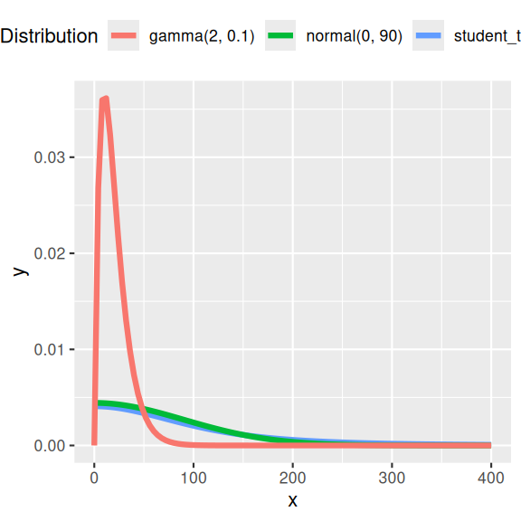

```r
standist::visualize("student_t(3, 0, 90)",
  "normal(0, 90)",
  "gamma(2, 0.1)",
  xlim = c(0, 400)
)
```

**Sample prior only**

I will also overlay the raw data for comparison.

```r
fert_form <- bf(YIELD ~ scale(FERTILIZER))
priors <- prior(normal(162, 90.4), class = "Intercept") +
  prior(normal(0, 90), class = "b") +
  prior(student_t(3, 0, 90.4), class = "sigma")
fert_brm2 <- brm(fert_form,
  data = fert,
  prior = priors,
  sample_prior = "only",
  iter = 5000,
  warmup = 1000,
  chains = 3, cores = 3,
  thin = 5,
  backend = "rstan",
  refresh = 0
)
```

**ggpredict**

```
Data points may overlap. Use the `jitter` argument to add some amount of
  random variation to the location of data points and avoid overplotting.
```

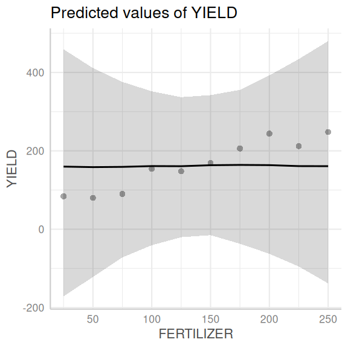

```r
fert_brm2 |>
  ggpredict() |>
  plot(show_data = TRUE)
```

**ggemmeans**

```
Data points may overlap. Use the `jitter` argument to add some amount of
  random variation to the location of data points and avoid overplotting.
```

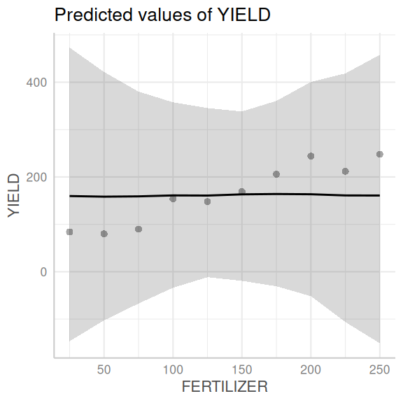

```r
fert_brm2 |>
  ggemmeans(~FERTILIZER) |>
  plot(show_data = TRUE)
```

**conditional_effects**

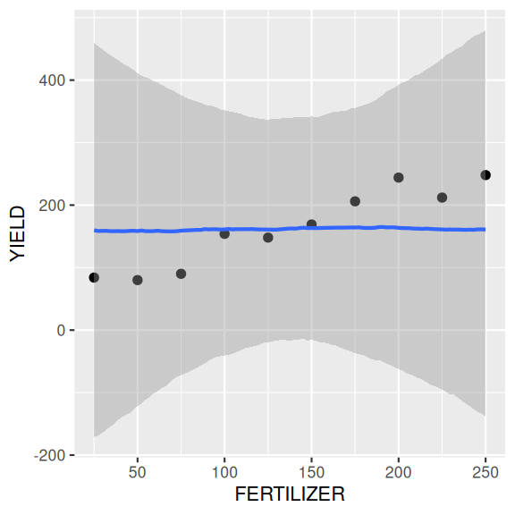

```r
fert_brm2 |>
  conditional_effects() |>
  plot(points = TRUE)
```

**Sample prior and posterior**

```r
fert_brm3 <- update(fert_brm2, sample_prior = "yes", refresh = 0)
```

```
The desired updates require recompiling the model
```

```r
# OR
fert_brm3 <- brm(fert_form,
  data = fert,
  prior = priors,
  sample_prior = "yes",
  iter = 5000,
  warmup = 1000,
  chains = 3, cores = 3,
  thin = 5,
  backend = "rstan",
  refresh = 0
)
```

**ggpredict**

```
Data points may overlap. Use the `jitter` argument to add some amount of
  random variation to the location of data points and avoid overplotting.
```

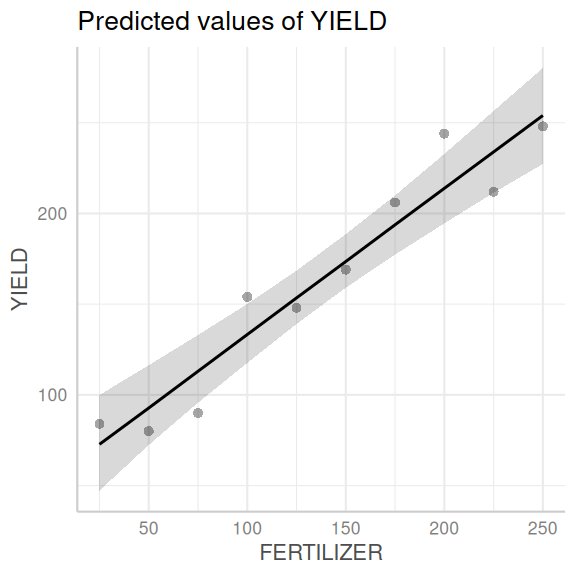

```r
fert_brm3 |>
  ggpredict() |>
  plot(show_data = TRUE)
```

**ggemmeans**

```
Data points may overlap. Use the `jitter` argument to add some amount of
  random variation to the location of data points and avoid overplotting.
```

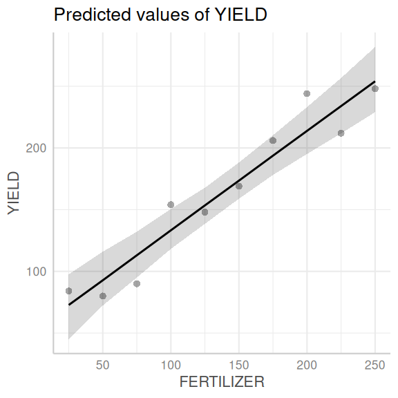

```r
fert_brm3 |>
  ggemmeans(~FERTILIZER) |>
  plot(show_data = TRUE)
```

**conditional_effects**

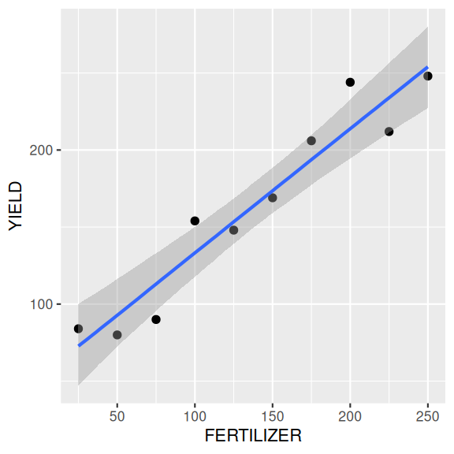

```r
fert_brm3 |>
  conditional_effects() |>
  plot(points = TRUE)
```

**Plotting prior and posterior**

When we have indicated that the posterior should be informed by both the prior and the posterior, both prior (governed by priors alone) and posterior (governed by both priors and data/likelihood) draws are returned. These can be compared by exploring the probabilities associated with specific hypotheses - the most obvious of which is that of no effect (that the parameter = 0).